# Estudis d'Informàtica, Multimedia i Telecomunicacions

### 4.1.5 Discretització variable edat en intervals:

Creem una nova variable discretitzada “segment_edat” que utilitzarem més endavant en anàlisis posteriors.

```r
trainData["segment_edat"] <- cut(trainData$Age, breaks = c(0,10,20,30,40,50,60,70,100), labels = c("0-9", "10-19", "20-29", "30-39","40-49","50-59","60-69","70-79"))
```

### 4.1.6 Gràfic:

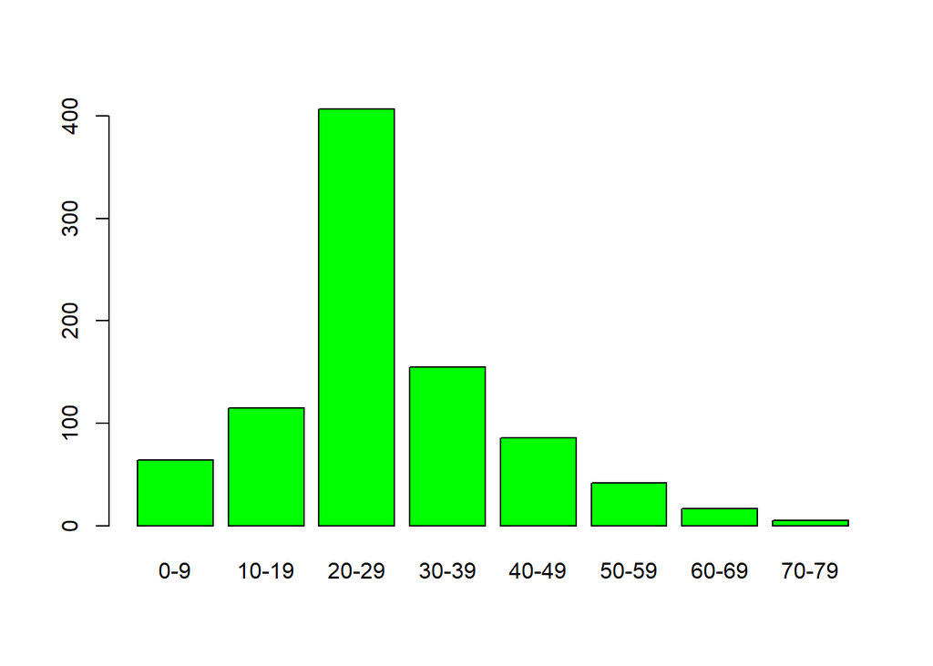

```r
plot(trainData$segment_edat, col="green")
```

# 5 Exercici 4:

## 5.1 Mètode d’agregació:

En aquest apartat farem un anàlisi de les dades utilitzant un mètode d’agregació. Obtindrem grups (clusters) que agrupen les dades segons la semblança entre elles. Primer de tot importem la llibreria:

```r
#Llibreria cluster per fer agrupacions
library(cluster)
```

La funció daisy() que utilitzarem per calcular la silueta de la mostra només funciona amb valors numèrics i l’atribut Sex és un string. Per solucionar aquest inconvenient farem un one-hot encoding transformant el Sex en dos nous atributs binaris:

```r
library(caret)
dummies <- predict(dummyVars(~ Sex, data = trainData), newdata = trainData)
trainData <- cbind(trainData, dummies)
summary(trainData)
```

```
##   PassengerId       Survived          Pclass          Name
##  Min.   :  1.0   Min.   :0.0000   Min.   :1.000   Length:891
##  1st Qu.:223.5   1st Qu.:0.0000   1st Qu.:2.000   Class :character
##  Median :446.0   Median :0.0000   Median :3.000   Mode  :character
##  Mean   :446.0   Mean   :0.3838   Mean   :2.309
##  3rd Qu.:668.5   3rd Qu.:1.0000   3rd Qu.:3.000
##  Max.   :891.0   Max.   :1.0000   Max.   :3.000
##
##      Sex                 Age            SibSp           Parch
##  Length:891         Min.   : 0.42   Min.   :0.000   Min.   :0.0000
##  Class :character   1st Qu.:22.00   1st Qu.:0.000   1st Qu.:0.0000
##  Mode  :character   Median :30.00   Median :0.000   Median :0.0000
##                     Mean   :29.76   Mean   :0.523   Mean   :0.3816
##                     3rd Qu.:35.00   3rd Qu.:1.000   3rd Qu.:0.0000
##                     Max.   :80.00   Max.   :8.000   Max.   :6.0000
##
##     Ticket               Fare           Cabin             Embarked
##  Length:891         Min.   :  0.00   Length:891         Length:891
##  Class :character   1st Qu.:  7.91   Class :character   Class :character
##  Mode  :character   Median : 14.45   Mode  :character   Mode  :character
##                     Mean   : 32.20
##                     3rd Qu.: 31.00
##                     Max.   :512.33
##
##   segment_edat   Sexfemale         Sexmale
##  20-29  :407   Min.   :0.0000   Min.   :0.0000
##  30-39  :155   1st Qu.:0.0000   1st Qu.:0.0000
##  10-19  :115   Median :0.0000   Median :1.0000
##  40-49  : 86   Mean   :0.3524   Mean   :0.6476
##  0-9    : 64   3rd Qu.:1.0000   3rd Qu.:1.0000
##  50-59  : 42   Max.   :1.0000   Max.   :1.0000
##  (Other): 22
```

```r
train_data <- trainData[ , c("Survived", "Pclass", "Sexfemale", "Sexmale", "Age")]
str(train_data)
```

```
## 'data.frame':    891 obs. of  5 variables:
##  $ Survived : int  0 1 1 1 0 0 0 0 1 1 ...
##  $ Pclass   : int  3 1 3 1 3 3 1 3 3 2 ...
##  $ Sexfemale: num  0 1 1 1 0 0 0 0 1 1 ...
##  $ Sexmale  : num  1 0 0 0 1 1 1 1 0 0 ...
##  $ Age      : num  22 38 26 35 35 30 54 2 27 14 ...
```

Passem a executar l’algorisme kmeans, com que inicialment no coneixem el nombre de clusters, provem d’aplicar l’algorisme amb 2, 3, 4, 5, 6, 7 i 8 clústers.

```r
train_data2       <- kmeans(train_data, 2)
passatgers_cluster2 <- train_data2$cluster

train_data3       <- kmeans(train_data, 3)
passatgers_cluster3 <- train_data3$cluster

train_data4       <- kmeans(train_data, 4)
passatgers_cluster4 <- train_data4$cluster

train_data5       <- kmeans(train_data, 5)
passatgers_cluster5 <- train_data5$cluster

train_data6       <- kmeans(train_data, 6)
passatgers_cluster6 <- train_data6$cluster

train_data7       <- kmeans(train_data, 7)
passatgers_cluster7 <- train_data7$cluster

train_data8       <- kmeans(train_data, 8)
passatgers_cluster8 <- train_data8$cluster
```

Podem veure gràficament els clusters obtinguts amb la següent funció:

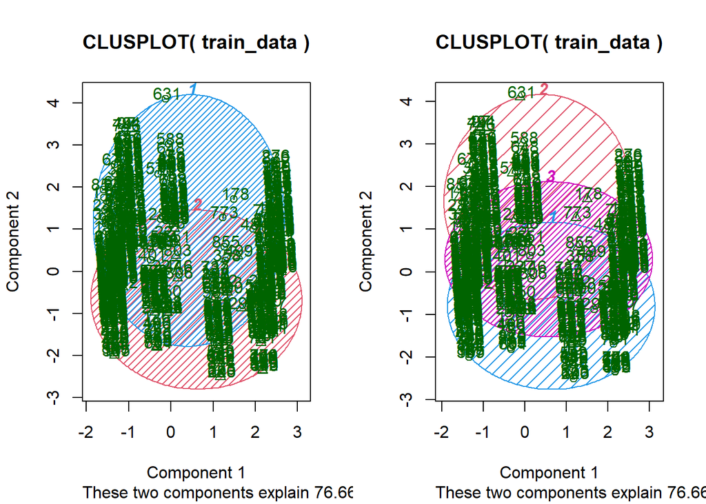

```r
library(plotfunctions)
par(mfrow=c(1,2))

clusplot(train_data, train_data2$cluster, color=TRUE, shade=TRUE, labels=2, lines=0)
clusplot(train_data, train_data3$cluster, color=TRUE, shade=TRUE, labels=2, lines=0)
```

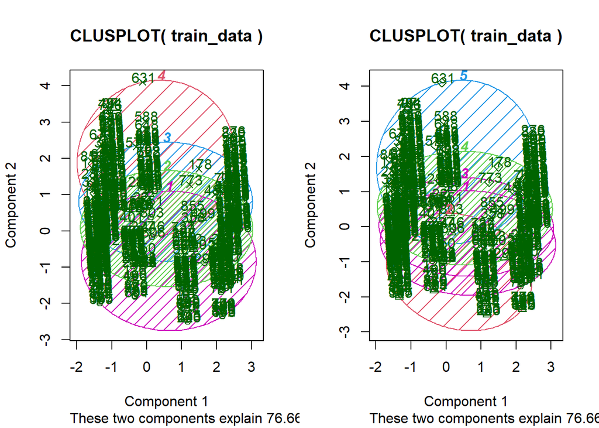

```r
clusplot(train_data, train_data4$cluster, color=TRUE, shade=TRUE, labels=2, lines=0)
clusplot(train_data, train_data5$cluster, color=TRUE, shade=TRUE, labels=2, lines=0)
```

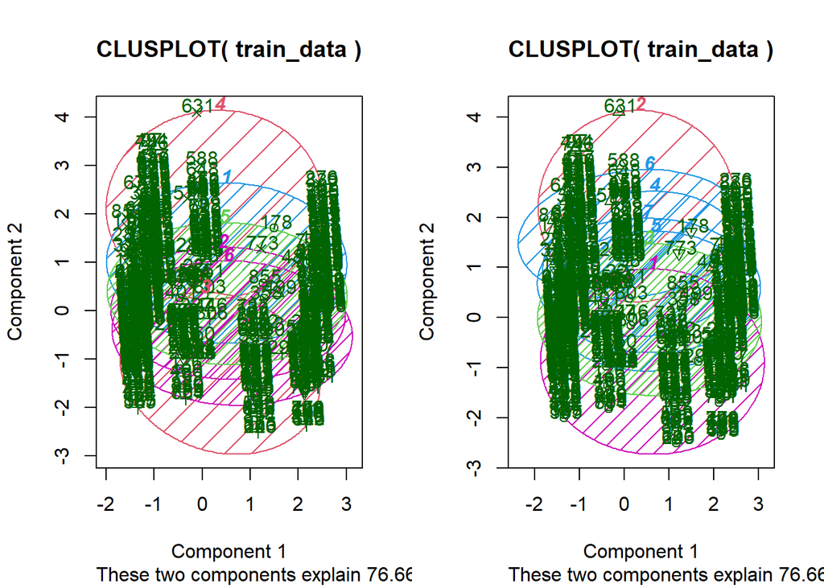

```r
clusplot(train_data, train_data6$cluster, color=TRUE, shade=TRUE, labels=2, lines=0)
clusplot(train_data, train_data7$cluster, color=TRUE, shade=TRUE, labels=2, lines=0)
```

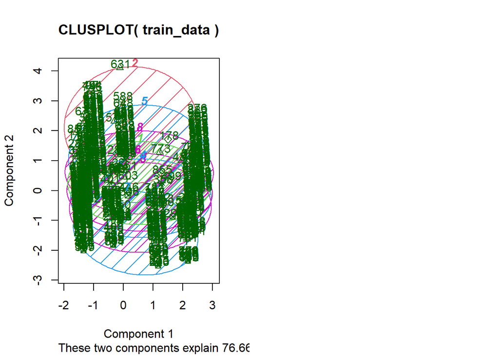

```r
clusplot(train_data, train_data8$cluster, color=TRUE, shade=TRUE, labels=2, lines=0)
```

Ara calcularem la silueta de les mostres per avaluar la qualitat del mètode d’agregació.

```r
set.seed(891)
d <- daisy(train_data)
resultados <- rep(0, 10)
for (i in c(2,3,4,5,6,7,8,9,10))
{
  fit           <- kmeans(train_data, i)
  y_cluster     <- fit$cluster
  sk            <- silhouette(y_cluster, d)
  resultados[i] <- mean(sk[,3])
}
```

Mostrem en un gràfica els valors de les siluetes mitjana de cada prova per a comprovar quin nombre de clústers és el millor.

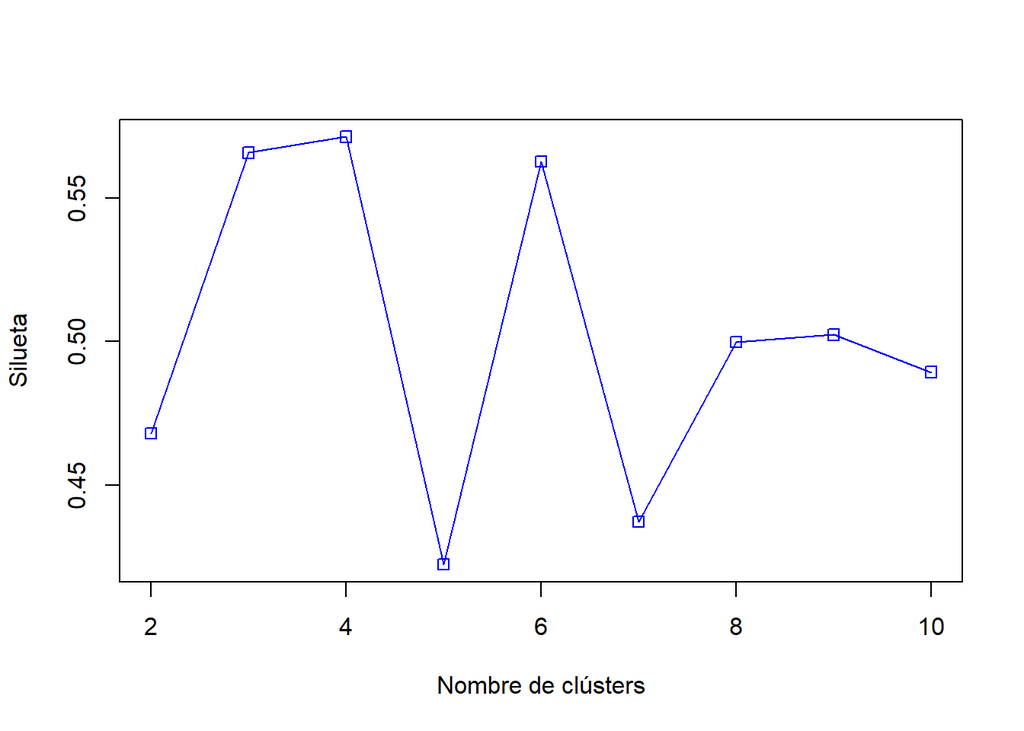

```r
plot(2:10,resultados[2:10],type="o",col="blue",pch=0,xlab="Nombre de clústers",ylab="Silueta")
```

Veiem que la millor agrupació és amb 4 clusters i la segona millor amb 3.

Per comparar resultats, provem de fer l’avaluació del millor nombre de clusters amb la funció withinss.

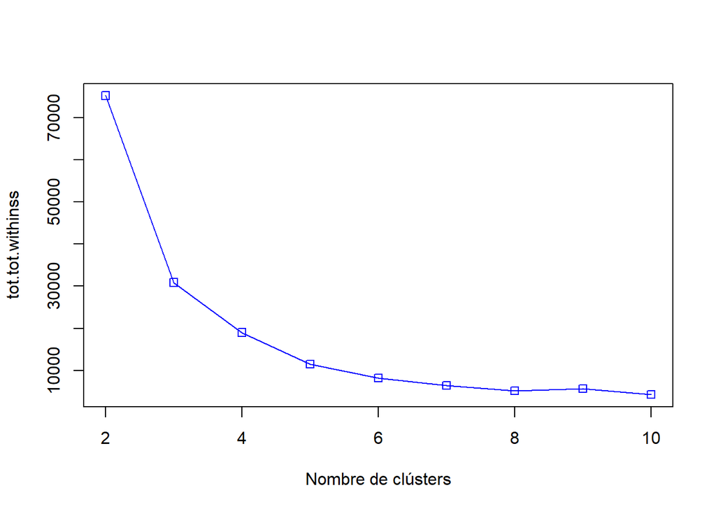

```r
resultados <- rep(0, 10)
for (i in c(2,3,4,5,6,7,8,9,10))
{
  fit           <- kmeans(train_data, i)
  resultados[i] <- fit$tot.withinss
}
plot(2:10,resultados[2:10],type="o",col="blue",pch=0,xlab="Nombre de clústers",ylab="tot.tot.withinss")
```

En aquesta funció hem de buscar el “colze” de la corba per tenir el millor valor de k. En aquest cas és difícil trobar el millor valor perquè el gràfic té una corba molt rodona i no hi ha cap colze clar, tot i que potser seria el 3 o el 4.

Per últim provarem de fer l’avaluació amb la funció kmeansruns utilitzant els criteris de silueta mitjana i de Calinski-Harabasz:

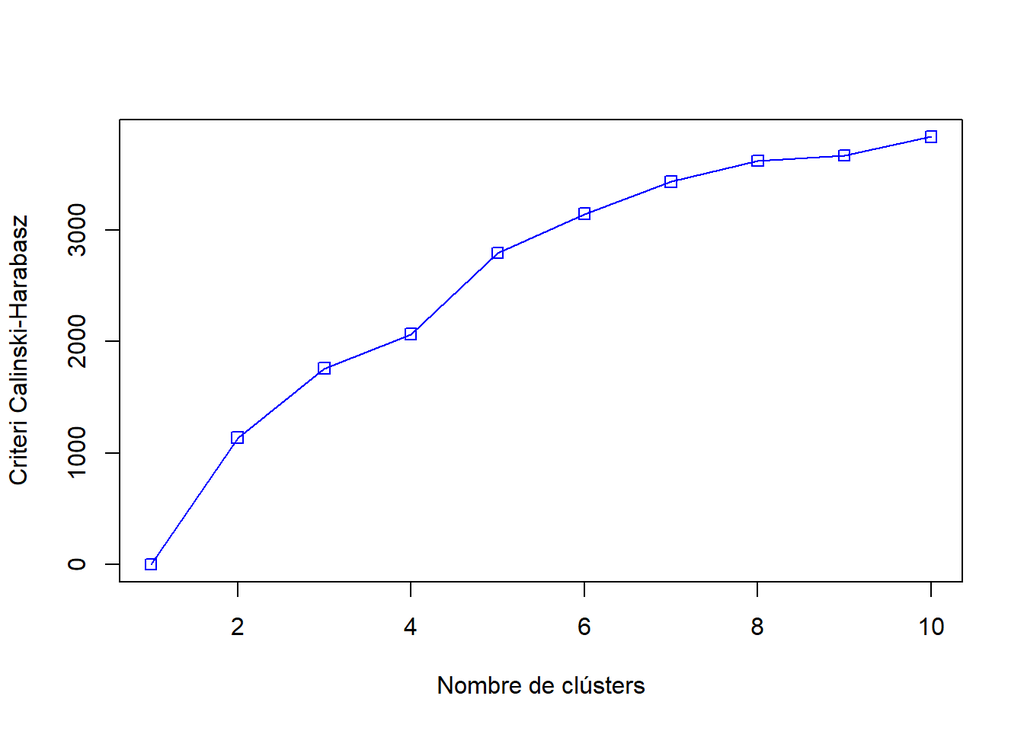

```r
library(fpc)
fit_ch  <- kmeansruns(train_data, krange = 1:10, criterion = "ch")
fit_asw <- kmeansruns(train_data, krange = 1:10, criterion = "asw")

plot(1:10,fit_ch$crit,type="o",col="blue",pch=0,xlab="Nombre de clústers",ylab="Criteri Calinski-Harabasz")
```

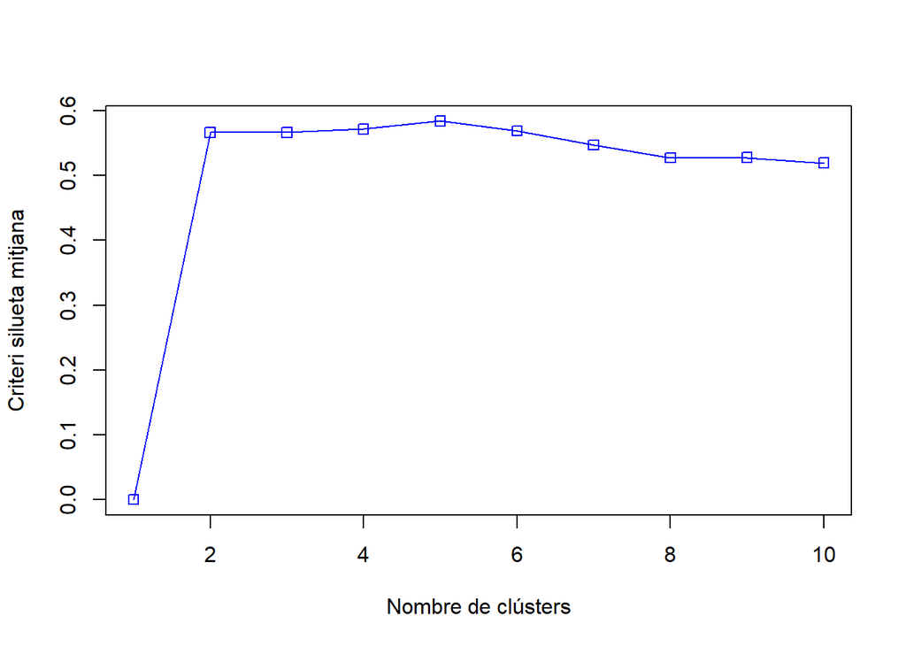

```r
plot(1:10,fit_asw$crit,type="o",col="blue",pch=0,xlab="Nombre de clústers",ylab="Criteri silueta mitjana")
```

En aquest cas el punt més alt és per k=5 i el segon és k=4, que és el que escollirem perquè ja ens havia sortit abans.

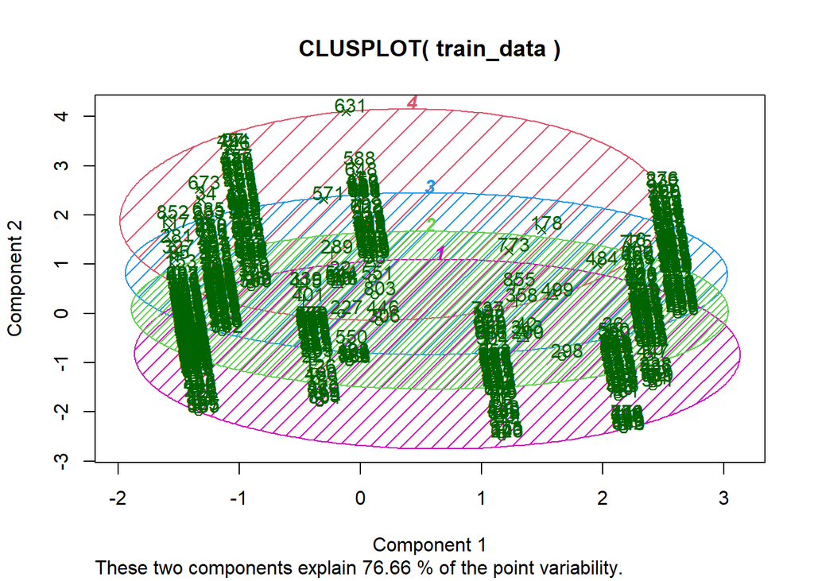

```r
clusplot(train_data, train_data4$cluster, color=TRUE, shade=TRUE, labels=2, lines=0)
```

Podem observar que els 4 clusters que s’han format es van solapant l’un amb l’altre, amb el cluster 4 una mica més separat a la part alta.

### 5.1.1 Arbres de decisió.

En aquest apartat crearem un conjunt de regles que ens determinaran la probabilitat de sobreviure dels passatgers. Utilitzarem el dataset de train per construir el model i el de test per validar-lo.

Per la visualització gràfica de les variables utilitzarem els paquets ggplot2, gridExtra i grid de R.

```r
if(!require(ggplot2)){
    install.packages('ggplot2', repos='http://cran.us.r-project.org')
    library(ggplot2)
}
if(!require(ggpubr)){
    install.packages('ggpubr', repos='http://cran.us.r-project.org')
    library(ggpubr)
}
if(!require(grid)){
    install.packages('grid', repos='http://cran.us.r-project.org')
    library(grid)
}
if(!require(gridExtra)){
    install.packages('gridExtra', repos='http://cran.us.r-project.org')
    library(gridExtra)
}
if(!require(C50)){
    install.packages('C50', repos='http://cran.us.r-project.org')
    library(C50)
}
```

A continuació construim l’arbre de decisió a partir del dataset d’entrenament. A la funció li passem com a primer paràmetre el subconjunt d’entrenament excloent el camp ‘Survived’ (train_data[-1]) i com a segon paràmetre el propi camp (train_data$Survived):

```r
set.seed(891)
train_data$Survived = as.factor(train_data$Survived)
model <- C50::C5.0(train_data[-1], train_data$Survived)
summary(model)
```

```
##
## Call:
## C5.0.default(x = train_data[-1], y = train_data$Survived)
##
##
## C5.0 [Release 2.07 GPL Edition]      Thu May 27 10:38:32 2021
## -------------------------------
##
## Class specified by attribute `outcome'
##
## Read 891 cases (5 attributes) from undefined.data
##
## Decision tree:
##
## Sexfemale <= 0:
## :...Age > 9: 0 (545/90)
## :   Age <= 9:
## :   :...Pclass <= 2: 1 (11)
## :       Pclass > 2: 0 (21/8)
## Sexfemale > 0:
## :...Pclass <= 2: 1 (170/9)
##     Pclass > 2:
##     :...Age <= 38: 1 (132/61)
##         Age > 38: 0 (12/1)
##
##
## Evaluation on training data (891 cases):
##
##      Decision Tree
##    ----------------
##    Size      Errors
##
##       6  169(19.0%)   <<
##
##
##     (a)   (b)    <-classified as
##    ----  ----
##     479    70    (a): class 0
##      99   243    (b): class 1
##
##
##  Attribute usage:
##
##  100.00% Sexfemale
##   80.92% Age
##   38.83% Pclass
##
##
## Time: 0.0 secs
```

Veiem que tenim 169 errors (un 19%), que indiquen el nombre de casos mal classificats.

La visualització de l’arbre obtingut és la següent:

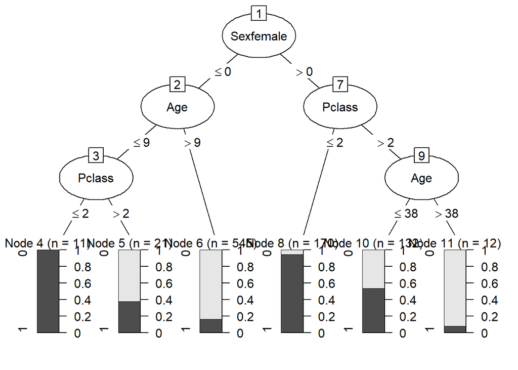

```r
plot(model)
```

En el gràfic podem veure esquemàticament els percentatges de supervivència en funció de les diferents variables. Ara descomposarem l’arbre en un set de regles amb el flag rules=TRUE:

```r
model2 <- C50::C5.0(train_data[-1], train_data$Survived, rules = TRUE)
summary(model2)
```

```
##
## Call:
## C5.0.default(x = train_data[-1], y = train_data$Survived, rules = TRUE)
##
##
## C5.0 [Release 2.07 GPL Edition]      Thu May 27 10:38:32 2021
## -------------------------------
##
## Class specified by attribute `outcome'
##
## Read 891 cases (5 attributes) from undefined.data
##
## Rules:
##
## Rule 1: (51/4, lift 1.5)
##  Pclass > 2
##  Age > 38
##  ->  class 0  [0.906]
##
## Rule 2: (577/109, lift 1.3)
##  Sexfemale <= 0
##  ->  class 0  [0.810]
##
## Rule 3: (11, lift 2.4)
##  Pclass <= 2
##  Sexfemale <= 0
##  Age <= 9
##  ->  class 1  [0.923]
##
## Rule 4: (314/81, lift 1.9)
##  Sexfemale > 0
##  ->  class 1  [0.741]
##
## Default class: 0
##
##
## Evaluation on training data (891 cases):
##
##          Rules
##    ----------------
##      No      Errors
##
##       4  169(19.0%)   <<
##
##
##     (a)   (b)    <-classified as
##    ----  ----
##     479    70    (a): class 0
##      99   243    (b): class 1
##
##
##  Attribute usage:
##
##  100.00% Sexfemale
##    6.96% Pclass
##    6.96% Age
##
##
## Time: 0.0 secs
```

Explicació de les regles:

- Regla 1: Pclass > 2, Age > 38 → Survived = 0. Validesa: 90,6%
- Regla 2: Sexfemale = 0 → Survived 0. Validesa: 81,0%
- Regla 3: Pclass <= 2, Sexfemale = 0, Age <= 9 → Survived 1. Validesa: 92,3%
- Regla 4: Sexfemale > 0 → Survived 1. Validesa: 74,1%

En general podem concloure que els passatgers de classe 1 i 2 i les dones en concret tenen moltes probabilitats de sobreviure, així com els nens menors de 9 anys.

A continuació carreguem les dades de test i les utilitzarem per avaluar quants supervivents hi hauria fent servir el model creat.

```r
testData <- read.csv('data/test.csv',stringsAsFactors = FALSE)
dummies <- predict(dummyVars(~ Sex, data = testData), newdata = testData)
testData <- cbind(testData, dummies)
dim(testData)
```

```
## [1] 418  13
```

```r
predicted_model <- predict( model, testData, type="class" )
summary(predicted_model)
```

```
##   0   1
## 266 152
```

Segons la predicció del model, 266 passatgers no sobreviuen i 152 sí.

### 5.1.2 Model de regressió:

Ara passem a avaluar la qualitat del primer model amb esbrinar si la regressió és lineal múltiple (amb regressors quantitatius i qualitatius). Carregem el conjunt de dades train_data per generar i esbrinar la qualitat del model amb la fòrmula de l’ajustament de regressió lineal lm().

```r
# Torno als valors de train.csv, perquè considero que per fer el model de regressió la variable dependent més significativa és Survived.

trainData <- read.csv('data/train.csv',stringsAsFactors = FALSE)
train_data <- trainData[ , c("Survived", "Pclass","Sex", "Age","Fare")]

# Considerem com a variable dependent, la variable Survived, la resta (Age, Sex, Fare i Pclass) les considerarem independents:

model <- lm(Survived ~ Sex + Age + Pclass+Fare, train_data ) #Generació i valoració del model.
summary(model)
```

```
##
## Call:
## lm(formula = Survived ~ Sex + Age + Pclass + Fare, data = train_data)
##
## Residuals:
##      Min       1Q   Median       3Q      Max
## -1.11594 -0.25268 -0.06392  0.22965  1.00662
##
## Coefficients:
##               Estimate Std. Error t value Pr(>|t|)
## (Intercept)  1.317e+00  7.699e-02  17.104  < 2e-16 ***
## Sexmale     -4.787e-01  3.084e-02 -15.518  < 2e-16 ***
## Age         -5.426e-03  1.091e-03  -4.975  8.2e-07 ***
## Pclass      -2.004e-01  2.250e-02  -8.907  < 2e-16 ***
## Fare         6.801e-05  3.321e-04   0.205    0.838
## ---
## Signif. codes:  0 '***' 0.001 '**' 0.01 '*' 0.05 '.' 0.1 ' ' 1
##
## Residual standard error: 0.3849 on 709 degrees of freedom
##   (177 observations deleted due to missingness)
## Multiple R-squared:  0.3902, Adjusted R-squared:  0.3868
## F-statistic: 113.4 on 4 and 709 DF,  p-value: < 2.2e-16
```

Avaluació de la bondat de l’ajust, a partir del coeficient de determinació o R^2 (R^2 indica el grau d’ajust de la recta de regressió als valors de la mostra): a partir dels resultats anteriors amb la funció summary(), podem veure que el seu valor és Multiple R-squared: 0.3902. Amb aquest valor tant lluny de 1 no podem dir que hi ha regressió lineal entre les variables.

El model amb totes les variables introduïdes com a predictors té un R^2 (Multiple R-squared) 0.3902, el qual és capaç d’explicar el 39% de la variabilitat observada en la variable dependent “Survived”. Com que no és molt proper al 100%, en principi no és un bon model. El p-value del model és significatiu (2.2e-16) perquè està molt per sota del 0.05 que és el valor d’alfa. Els asterics volen dir que tant la variable SexMale (els homes en aquest cas), com Pclass i Age són significatives per al resultat del model. La variable Fare no és significativa per al model.

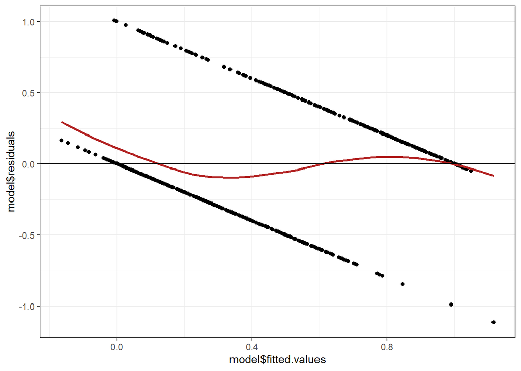

```r
# Representació gràfica del model:

ggplot(model,aes(model$fitted.values,model$residuals)) + geom_point() + geom_smooth(color = "firebrick", se = FALSE) + geom_hline(yintercept = 0) + theme_bw()
```

# 6 Interpretació del resultat del gràfic:

```r
confint(model) # Mostra de l'interval de confiança per cadascun dels coeficients parcials de regressió.
```

```
##                     2.5 %        97.5 %
## (Intercept)  1.1657399681  1.4680632744
## Sexmale     -0.5392228726 -0.4181063037
## Age         -0.0075668185 -0.0032843985
## Pclass      -0.2445946093 -0.1562399160
## Fare        -0.0005840531  0.0007200638
```

### 6.0.1 Comprovació de la normalitat i homogeneïtat de la variància (homoscedasticitat).

```r
shapiro.test(trainData$Survived) # Test de Shapiro.
```

```
##
##  Shapiro-Wilk normality test
##
## data:  trainData$Survived
## W = 0.61666, p-value < 2.2e-16
```

Test de normalitat Shapiro on el p-valor (2.2e-16) resultant de la prova és més petit que el nivell de significació (0.05), això vol dir que s’observen diferències estadísticament significatives entre el grup de dades trainData per a la variable Survived.

```r
library(car)

fligner.test(Survived ~ Age, data=trainData) # Test d'homogeneitat de les variables Survived i Age.
```

```
##
##  Fligner-Killeen test of homogeneity of variances
##
## data:  Survived by Age
## Fligner-Killeen:med chi-squared = 73.115, df = 87, p-value = 0.8562
```

Com que la prova té un p-valor (0.8562) molt superior al nivell de significació (0.05), no es rebutja la hipòtesi nul·la d’homoscedasticitat i es conclou que la variable Age presenta variàncies estadísticament iguals o similars per als grups de Survived.

```r
fligner.test(Survived ~ Sex, data=trainData) # Test d'homogeneitat de les variables Survived i Sex.
```

```
##
##  Fligner-Killeen test of homogeneity of variances
##
## data:  Survived by Sex
## Fligner-Killeen:med chi-squared = 5.7729, df = 1, p-value = 0.01627
```

Com que la prova té un p-valor (0.01627), inferior al nivell de significació (0.05), es rebutja la hipòtesi nul·la d’homoscedasticitat i es conclou que la variable Sex no presenta variàncies estadísticament similars per als grups de Survived.

```r
fligner.test(Survived ~ Pclass, data=trainData) # Test d'homogeneitat de les variables Survived i Pclass.
```

```
##
##  Fligner-Killeen test of homogeneity of variances
##
## data:  Survived by Pclass
## Fligner-Killeen:med chi-squared = 35.766, df = 2, p-value = 1.712e-08
```

Com que la prova té un p-valor (1.712e-08) molt inferior al nivell de significació (0.05), es rebutja la hipòtesi nul·la d’homoscedasticitat.

```r
fligner.test(Survived ~ Fare, data=trainData) # Test d'homogeneitat de les variables Survived i Fare.
```

```
##
##  Fligner-Killeen test of homogeneity of variances
##
## data:  Survived by Fare
## Fligner-Killeen:med chi-squared = 258.22, df = 247, p-value = 0.299
```

Com que la prova té un p-valor (0.299) superior al nivell de significació (0.05), no es rebutja la hipòtesi nul·la d’homoscedasticitat.

```r
### Proves de contrast d’hipòtesis, correlacions, regressions, etc. Aplicar almenys tres mètodes d’anàlisi diferents.
```

# 7 Exercici 5:

Ja hem anat posant gràfics i taules abans, crec que no cal aquest apartat.

# 8 Exercici 6:

## 8.1 Contribucions a la pràctica:

```r
tab <- matrix(c('Vicenç i Begoña', 'Vicenç i Begoña', 'Vicenç i Begoña'), ncol=1, byrow=TRUE)
colnames(tab) <- c('Firma')
rownames(tab) <- c('Investigació prèvia','Redacció de les respostes','Desenvolupament codi')
tab <- as.table(tab)
tab
```

```
##                           Firma
## Investigació prèvia       Vicenç i Begoña
## Redacció de les respostes Vicenç i Begoña
## Desenvolupament codi      Vicenç i Begoña
```